# Neoantigen Prediction 4

# Using ESTIMATE to Calculate Immune Score

[ESTIMATE](https://bioinformatics.mdanderson.org/public-software/estimate/) (**E**stimation of **ST**romal and **I**mmune cells in **MA**lignant **T**umor tissues using **E**xpression data) is an R-based tool for calculating immune score. So, what’s immune score in the first place? According to this [article by Jérôme Galon, et al.](https://www.ncbi.nlm.nih.gov/pmc/articles/PMC3269368/), called “The immune score as a new possible approach for the classification of cancer”, the authors suggest a new way of classifying cancer based on a thing named *immune score*. Usually, the outcome prediction in cancer is done by examining and evaluating tissue samples obtained during surgical removal of the primary tuomr focusing on their histopathological characteristics. Tumor staging ([AJCC/UICC-TNM classification](https://www.uicc.org/resources/tnm), [Wikipedia article: TNM staging system](https://en.wikipedia.org/wiki/TNM_staging_system)) classification was developed and maintained by the Union for International Cancer Control (UICC) and also is used by the American Joing Committee on Cancer (AJCC) and International Federation of Gynecology and Obstetrics (FIGO). This system is a global standard for classifying the extent of spread of cancer by stage through the anatomical extent of tumor cancers. It has gained wide international acceptance for many solid tumor cancers, but unfortunately not applicable to leukaemia and tumors in the CNS (central nervous system). TNM system goes like this: data on tumor burden (T), presence of cancer cells in draining and regional lymph nodes (N), and evidence for metastases (M). The thing about the histopathological analysis of tumor tissue reveals that tumors are often infiltrated by a variable degree of inflammatory and lymphocytic cells. Closer look reveals that these immune cells are not distributed randomly, but seem to be organized in more or less dense infiltrates in the center of the tumoral zone (CT), at the invasive margin (IM) of tumoral nests and in lymphoid islets adjacent to the tumor. Broad signatures of inflammation can tell us a lot about the biology of tumor. This signature includes evidence for innate immune activation, chemokines for T cell recruitment, immune effector molecules, and expression of immune regulatory factors. Global analysis of the tumor microenvironment showed that the immune contexture, i.e. the nature, functional orientation, density, and location of adaptive immune cells within distinct tumor regions influence the risk of relapse. Immune classification of tumors was proposed based on a simple score, quantifying the density and location of immune-cells within the tumor. This immune-classification has a prognostic value that may be superior to AJCC/UICC TNM-classification. Immune score basically tells us the quantitative representation of inflmmation for evaluation.

ESTIMATE provides researchers with scores for 1) tumor purity, 2) the level of stromal cells[^1] present, and the 3) infiltration level of immune cells in tumor tissues based on expression data.

In summary, ESTIMATE algorithm predicts and generates three following scores based on single sample Gene Set Enrichment Analysis (single-sample GSEA):

1. stromal score (that captures the presence of stroma in tumor tissue),
2. immune score (that represents the infiltration of immune cells in tumor tissue), and
3. estimate score (that infers tumor purity).

The algorithm presumes the data is obtained from Affymetrix, but also can be used for properly normalized RNA-seq data. Here’s a good read on this issue on biostars: https://www.biostars.org/p/279853/.

Heads up, the following procedure is from [ESTIMATE vignette documentation](https://rdrr.io/rforge/estimate/f/inst/doc/ESTIMATE_Vignette.pdf) in rforge.

## Load libraries for practice

```r
library(estimate) # ESTIMATE library for calculation
library(ggplot2)
library(gridExtra)
```

You’ll notice package called `gridExtra`. `ggplot2` uses `grid` package to generate graphics. `gridExtra` package provides a few additional functions that come in handy. For example, you can place multiple graphs in the virtual page.

Let’s open **GeneExpression.txt**. This data is obtained from 10 ovaraian cancer samples using Affymetrix U133Plus2.0 platform. (Note that the data is also already pre-included in the package that you can load it over a `system.file` command, `OvarianCancerExpr <- system.file("extdata", "sample_input.txt", package="estimate")`.)

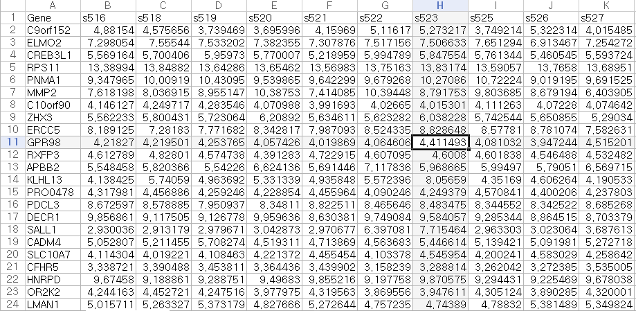

You can see in the picture that gene expression values are sorted by samples (s516, s518, …).

Now, use `filterCommonGenes` function on gene expression data to filter for only the common genes. The row name in an input data must be gene symbols or Entrez gene IDs.

```r
filterCommonGenes(input.f="GeneExpression.txt", output.f="OV_10412genes.gct", id="GeneSymbol")
```

```
## [1] "Merged dataset includes 10412 genes (0 mismatched)."
```

```r
# filter for common genes.
```

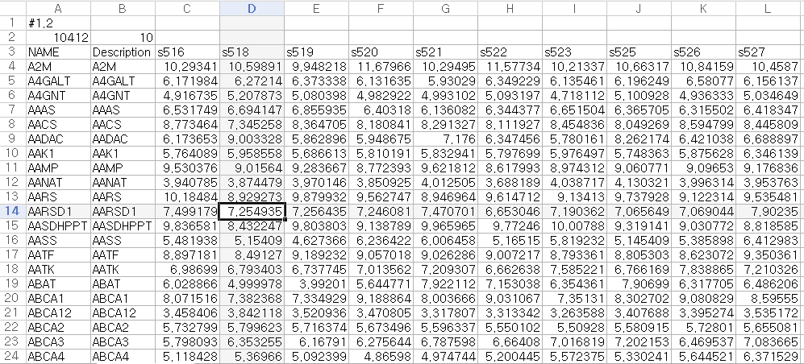

```r
estimateScore("OV_10412genes.gct", "OV_estimate_score.gct", platform="affymetrix") #Score calculation
```

```
## [1] "1 gene set: StromalSignature  overlap= 141"
## [1] "2 gene set: ImmuneSignature  overlap= 141"
```

Once we ccalculate tumor purity, we can view the association between raw ESTIMATE score and tumor purity.

```r
plotPurity(scores="OV_estimate_score.gct", samples="s516", platform="affymetrix") #Tumor Purity Plot drawing.
```

```
## Plotting tumor purity based on ESTIMATE score
```

The purity plot is stored in **estimated_purity_plots** sub-directory.

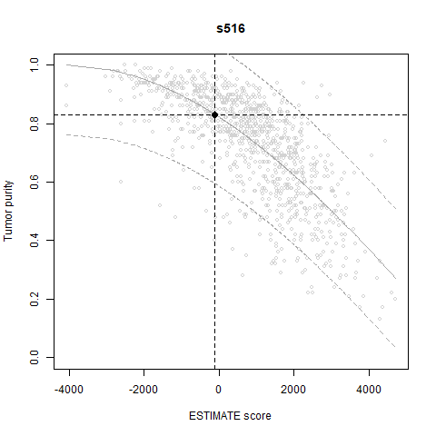

You can see this if you look into the function `plotPurity`:

```
plotPurity <- function(scores,
                       samples="all_samples",
                       platform=c("affymetrix", "agilent", "illumina"),
                       output.dir="estimated_purity_plots") { ...
     ...}
...
## Create output directory
dir.create(output.dir)
```

## Running time

Finally, here’s a little tip on how to show the running time of the whole program by using `proc.time()`.

```r
ptm <- proc.time()
estimateScore("OV_10412genes.gct", "OV_estimate_score.gct", platform="affymetrix")
```

```
## [1] "1 gene set: StromalSignature  overlap= 141"
## [1] "2 gene set: ImmuneSignature  overlap= 141"
```

```r
proc.time()-ptm
```

```
##    user  system elapsed
##    0.19    0.00    0.19
```

# Visualization of ESTIMATE score results

Earlier practice was about calculating scores for each sample, using samples’ expression data. Assume that we have calculated all TCGA samples’ (total 8,829 of them) scores (stromal score, immune [infiltration] score, ESTIMATE [tumor purity] score) scores with their gene expression data. The file **TCGA_ESTIMATE_CLINICAL.txt** contains this information.

**TCGA_ESTIMATE_CLINICAL.txt** file looks like below.

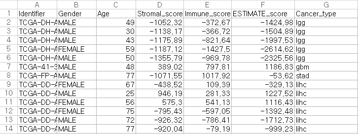

```r
TCGAEstimate <- read.table("TCGA_ESTIMATE_CLINICAL.txt", header=T, '\t', row.names=1)
#input file loaded (8829 people)
```

## Scores by Cancer Type

### Stromal score by cancer type

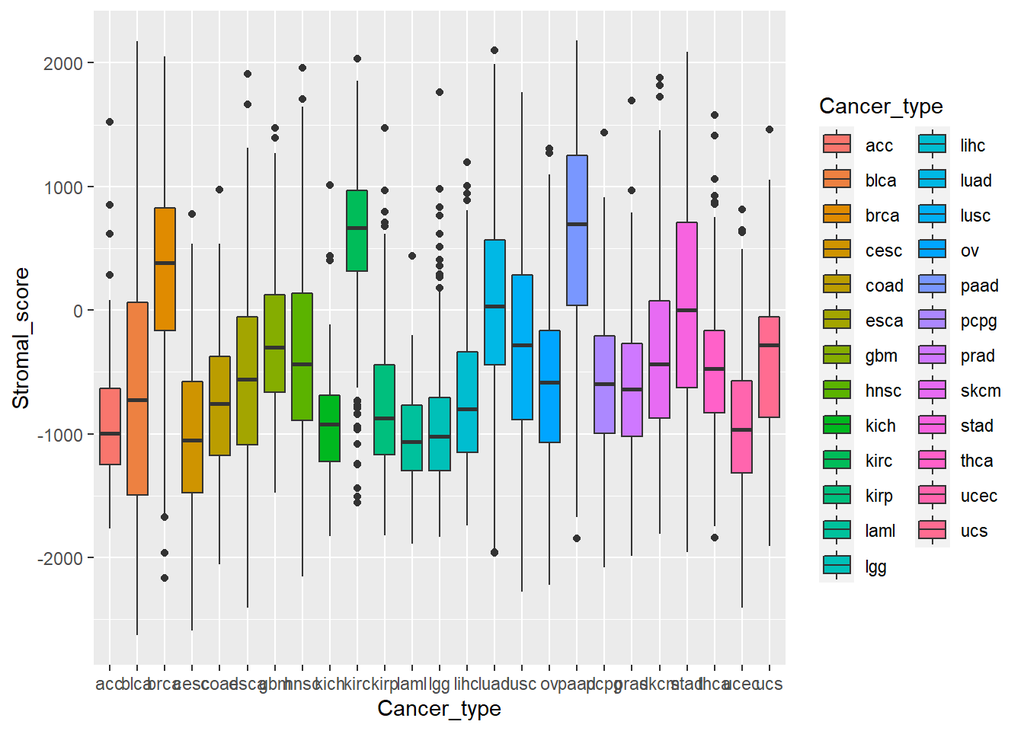

```r
# Boxplot visualization of scores by cancer type
stromal_cancer <- ggplot(TCGAEstimate, aes(x=Cancer_type, y=Stromal_score, fill=Cancer_type)) + geom_boxplot()

stromal_cancer
```

### Immune score by cancer type

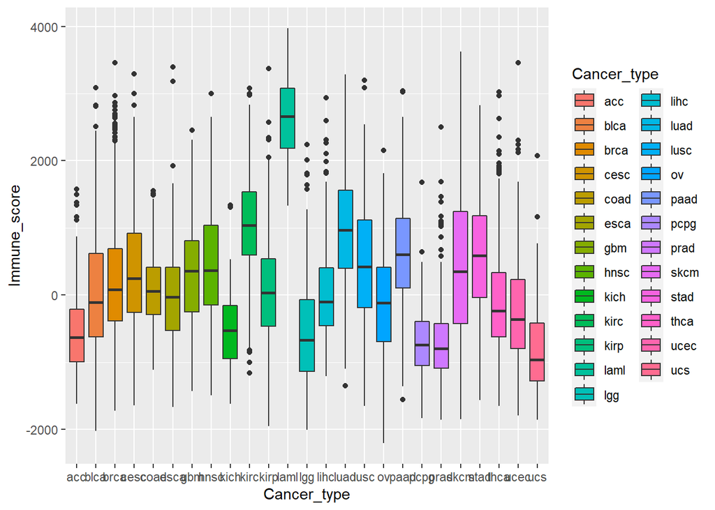

```r
immune_cancer <- ggplot(TCGAEstimate, aes(x=Cancer_type, y=Immune_score, fill=Cancer_type)) + geom_boxplot()

immune_cancer
```

### ESTIMATE score by cancer type

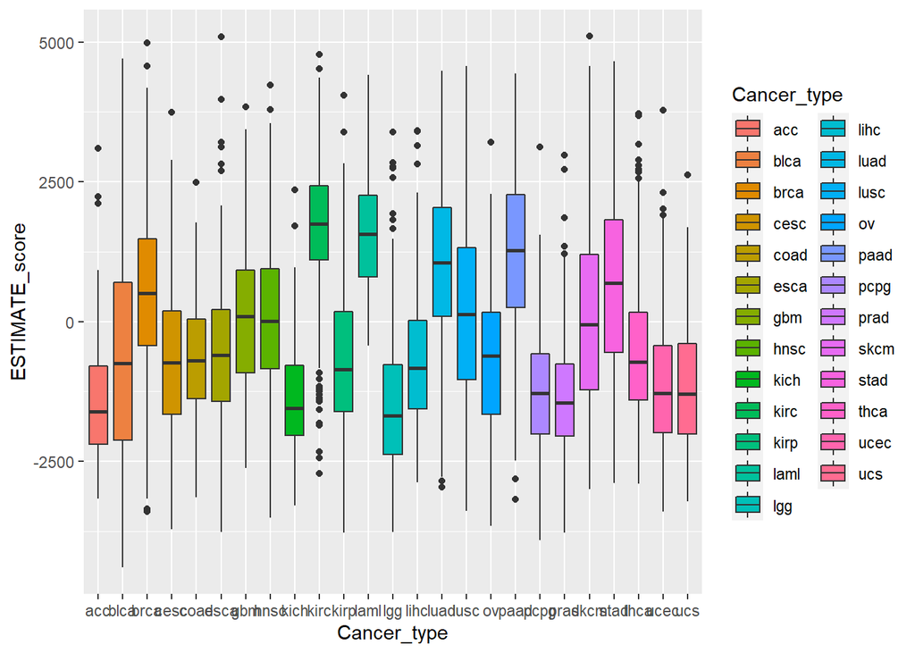

```r
estimate_cancer <- ggplot(TCGAEstimate, aes(x=Cancer_type, y=ESTIMATE_score, fill=Cancer_type)) + geom_boxplot()

estimate_cancer
```

Now Check if scores differ by gender (sex).

## Scores by Gender

Test if each scores have significant difference via t-test.

```r
t.test(Stromal_score ~ Gender, data= TCGAEstimate) # analyze by Gender
```

```
##
##  Welch Two Sample t-test
##
## data:  Stromal_score by Gender
## t = 6.6304, df = 8824.3, p-value = 3.544e-11
## alternative hypothesis: true difference in means is not equal to 0
## 95 percent confidence interval:
##   82.55834 151.86357
## sample estimates:
## mean in group FEMALE   mean in group MALE
##            -282.6085            -399.8195
```

```r
t.test(Immune_score ~ Gender, data = TCGAEstimate)
```

```
##
##  Welch Two Sample t-test
##
## data:  Immune_score by Gender
## t = 0.59767, df = 8762.7, p-value = 0.5501
## alternative hypothesis: true difference in means is not equal to 0
## 95 percent confidence interval:
##  -29.07773  54.58653
## sample estimates:
## mean in group FEMALE   mean in group MALE
##             236.5529             223.7985
```

```r
t.test(ESTIMATE_score ~ Gender, data = TCGAEstimate)
```

```
##
##  Welch Two Sample t-test
##
## data:  ESTIMATE_score by Gender
## t = 3.747, df = 8765.6, p-value = 0.0001801
## alternative hypothesis: true difference in means is not equal to 0
## 95 percent confidence interval:
##   61.97435 197.95660
## sample estimates:
## mean in group FEMALE   mean in group MALE
##            -46.05554           -176.02101
```

One can see that only stromal score and estimate score but not immune score by gender makes the cut-off p-value of 0.05. Therefore, not really a lot of significant difference by gender is observed in immune score.

### Stromal score by gender

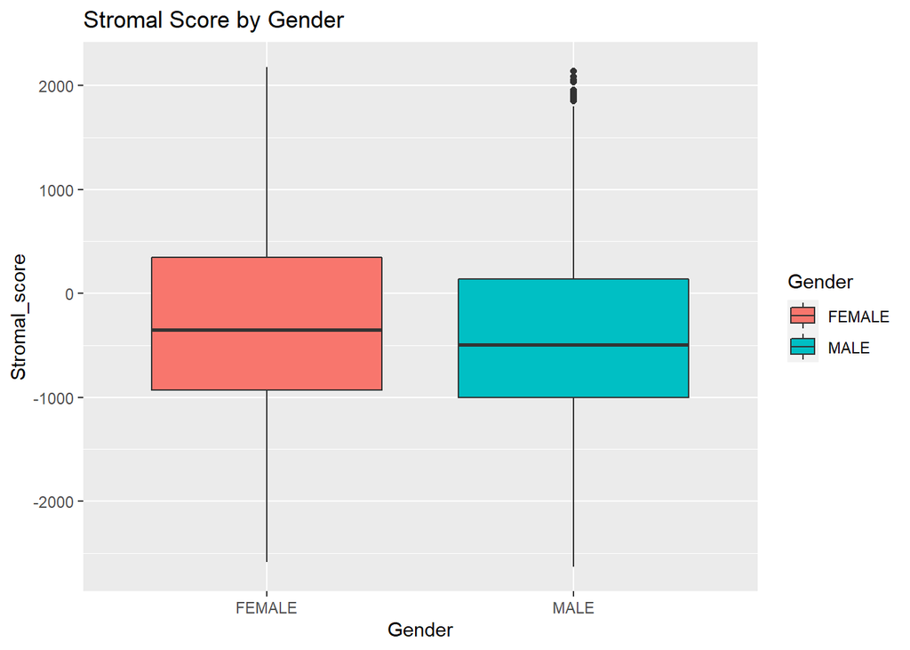

```r
stromal_gender <- ggplot(TCGAEstimate, aes(x=Gender, y=Stromal_score, fill=Gender)) + geom_boxplot() + ggtitle("Stromal Score by Gender")
stromal_gender
```

### Immune score by gender

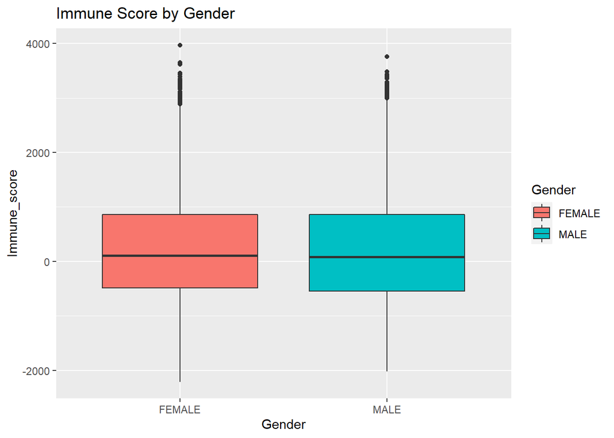

```r
immune_gender <- ggplot(TCGAEstimate, aes(x=Gender, y=Immune_score, fill=Gender)) + geom_boxplot() + ggtitle("Immune Score by Gender")
immune_gender
```

### ESTIMATE score by gender

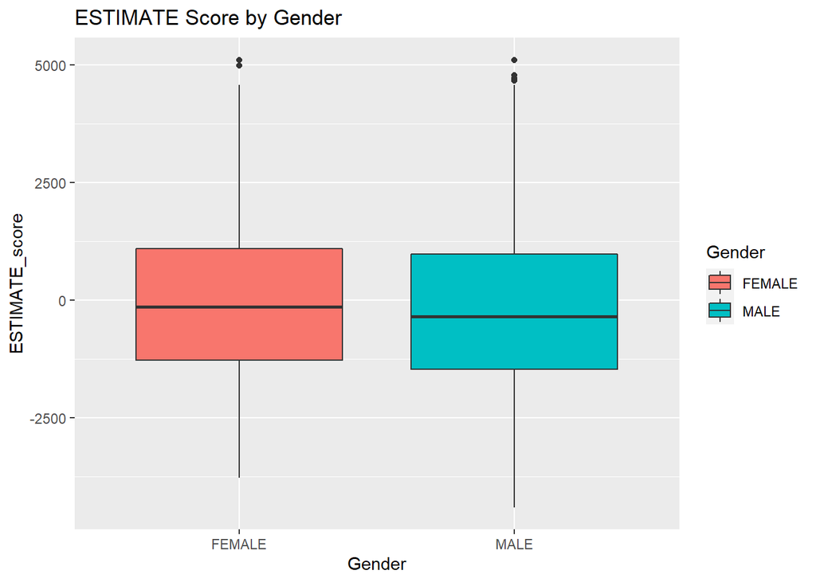

```r
estimate_gender <- ggplot(TCGAEstimate, aes(x=Gender, y=ESTIMATE_score, fill=Gender)) + geom_boxplot() + ggtitle("ESTIMATE Score by Gender")
estimate_gender
```

### All arranged into one

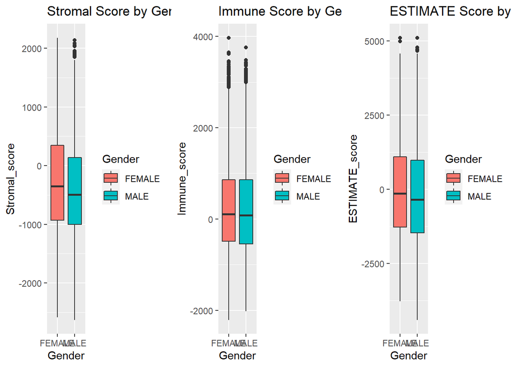

```r
grid.arrange(stromal_gender, immune_gender, estimate_gender, nrow=1, ncol=3)
```

## Scores by age

Since age is a continuous variable, we need to take a different approach by taking the median, and comparing if there is a significant difference between group of people with younger age than median and group of people with older age than median value.

```r
median_age <- median(as.numeric(TCGAEstimate$Age))
age_cat <- rep("low", dim(TCGAEstimate)[1]) # rep returns a vector with repeated values
# set all values to "low"
age_cat[which(as.numeric(TCGAEstimate$Age) > median_age)] <- "high"
# set all values that have higher age than the median age to "high"

# Add new column with age designation to TCGAEstimate data frame.
TCGAEstimate$age_cat <- age_cat
```

On a side note, `rep`, `seq`, and `cbind` are powerful basic functions in R, with applications in a wide variety of tasks. `rep` repeats characters and `seq` creates a sequence of characters. `rep` takes in two parameters, the value to be repeated and the number of times to repeat that value.

T-test if there are significant differences in each score.

**Actually, I have to make a correction here, because of not available age values in `TCGAEstimate$Age` column.**

Redo

```r
TCGAEstimate_age_corrected <- data.frame(matrix(NA, nrow=sum(TCGAEstimate$Age!="[Not Available]"), ncol=4))
```

```r
rownames(TCGAEstimate_age_corrected) <- rownames(TCGAEstimate)[TCGAEstimate$Age!="[Not Available]"]
colnames(TCGAEstimate_age_corrected) <- c("Age", "Stromal_score", "Immune_score", "ESTIMATE_score")
TCGAEstimate_age_corrected$Age <- TCGAEstimate$Age[TCGAEstimate$Age!="[Not Available]"]
TCGAEstimate_age_corrected$Stromal_score <- TCGAEstimate$Stromal_score[TCGAEstimate$Age!="[Not Available]"]
TCGAEstimate_age_corrected$Immune_score <- TCGAEstimate$Immune_score[TCGAEstimate$Age!="[Not Available]"]
TCGAEstimate_age_corrected$ESTIMATE_score <- TCGAEstimate$ESTIMATE_score[TCGAEstimate$Age!="[Not Available]"]
```

```r
TCGAEstimate_age_corrected
```

```
##              Age Stromal_score Immune_score ESTIMATE_score
## TCGA-DH-A7UV  49      -1052.32      -372.67       -1424.98
## TCGA-DH-A7UT  30      -1138.17      -366.72       -1504.89
## TCGA-DH-A7UU  43      -1175.89      -821.64       -1997.53
## TCGA-DH-A7UR  59      -1187.12     -1427.50       -2614.62
## TCGA-DH-A7US  50      -1355.79      -969.78       -2325.56
## TCGA-41-3915  48        389.02       797.81        1186.83
## TCGA-FP-A9TM  77      -1071.55      1017.92         -53.62
## TCGA-DD-A4NA  67       -438.52       109.39        -329.13
## TCGA-DD-A4NB  25        946.19       281.33        1227.52
## TCGA-DD-A4ND  56        575.30       541.13        1116.43
## TCGA-DD-A4NE  75       -795.43      -597.05       -1392.48
## TCGA-DD-A4NF  72       -926.32      -786.41       -1712.73
## TCGA-DD-A4NG  77       -920.04       -79.19        -999.23
## TCGA-B0-5084  33       -508.47       196.54        -311.93
## TCGA-DD-A4NI  67       -188.44       445.41         256.97
## TCGA-DD-A4NJ  54       -248.04       361.78         113.74
## TCGA-DD-A4NK  80       -747.03      -540.25       -1287.29
## TCGA-DD-A4NL  46       -268.75      -111.58        -380.33
## TCGA-B0-5081  79       1280.68      2566.31        3846.99
## TCGA-DD-A4NN  56       -949.02      -831.75       -1780.77
## TCGA-DD-A4NO  65       -424.72      -339.60        -764.32
## TCGA-DD-A4NP  32       -803.70      -298.01       -1101.71
## TCGA-DD-A4NQ  60      -1089.01       101.76        -987.25
## TCGA-DD-A4NR  85         54.00      1836.16        1890.16
## TCGA-DD-A4NS  61        526.88       581.45        1108.33
## TCGA-DD-A4NV  61       -232.06      -257.35        -489.42
## TCGA-A3-A8OX  65        998.80      1203.69        2202.49
## TCGA-A3-A8OW  37        480.77       697.74        1178.50
## TCGA-A3-A8OV  75         57.65       692.21         749.86
## TCGA-A3-A8OU  74        631.85       917.30        1549.15
## TCGA-67-3771  77        271.68      1066.71        1338.39
## TCGA-67-3770  70       -189.50      1238.99        1049.50
## TCGA-67-3773  84        422.70      1548.55        1971.25
## TCGA-67-3772  82        771.41      1171.82        1943.23
## TCGA-67-3774  73         -6.81      1124.26        1117.45
## TCGA-AB-2932  62       -791.81      3224.63        2432.82
## TCGA-VS-A9UJ  55      -1608.69     -1362.79       -2971.48
## TCGA-LL-A50Y  84       -167.88       381.93         214.05
## TCGA-L9-A8F4  64         85.67      1507.06        1592.73
```

[output cut: 8729 more lines]

```
## TCGA-E7-A97Q  60       -202.36      -222.12        -424.48
## TCGA-22-1002  69        424.72       807.73        1232.44
## TCGA-22-1000  76       1478.49      1908.01        3386.50
## TCGA-86-A4P8  59        914.62      2466.21        3380.83
## TCGA-22-1005  63        727.59      2466.57        3194.16
## TCGA-ZJ-AB0H  48       -409.69      1240.11         830.42
## TCGA-ZJ-AB0I  25      -1244.41       186.79       -1057.62
## TCGA-XV-AB01  54         74.80       653.04         727.84
## TCGA-LT-A8JT  69      -1590.41      -267.87       -1858.28
## TCGA-AO-A0JL  59       -108.00      -571.53        -679.53
## TCGA-AB-2936  61      -1165.61      2738.40        1572.79
## TCGA-HD-8314  58        -90.09       652.29         562.21
## TCGA-CU-A3KJ  75      -1142.01        18.95       -1123.07
## TCGA-VR-A8Q7  60       -817.96       220.73        -597.24
## TCGA-EC-A1NJ  73       -212.80       551.66         338.86
```

```r
median_age_corrected <- median(as.numeric(TCGAEstimate_age_corrected$Age))
age_cat_corrected <- rep("low", dim(TCGAEstimate_age_corrected)[1])
age_cat_corrected[which(as.numeric(TCGAEstimate_age_corrected$Age)> median_age_corrected)] <- "high"
TCGAEstimate_age_corrected$age_cat_corrected <- age_cat_corrected
```

```r
TCGAEstimate_age_corrected
```

```
##              Age Stromal_score Immune_score ESTIMATE_score age_cat_corrected
## TCGA-DH-A7UV  49      -1052.32      -372.67       -1424.98               low
## TCGA-DH-A7UT  30      -1138.17      -366.72       -1504.89               low
## TCGA-DH-A7UU  43      -1175.89      -821.64       -1997.53               low
## TCGA-DH-A7UR  59      -1187.12     -1427.50       -2614.62               low
## TCGA-DH-A7US  50      -1355.79      -969.78       -2325.56               low
## TCGA-41-3915  48        389.02       797.81        1186.83               low
## TCGA-FP-A9TM  77      -1071.55      1017.92         -53.62              high
## TCGA-DD-A4NA  67       -438.52       109.39        -329.13              high
## TCGA-DD-A4NB  25        946.19       281.33        1227.52               low
## TCGA-DD-A4ND  56        575.30       541.13        1116.43               low
## TCGA-DD-A4NE  75       -795.43      -597.05       -1392.48              high
## TCGA-DD-A4NF  72       -926.32      -786.41       -1712.73              high
## TCGA-DD-A4NG  77       -920.04       -79.19        -999.23              high
## TCGA-B0-5084  33       -508.47       196.54        -311.93               low
## TCGA-DD-A4NI  67       -188.44       445.41         256.97              high
## TCGA-DD-A4NJ  54       -248.04       361.78         113.74               low
## TCGA-DD-A4NK  80       -747.03      -540.25       -1287.29              high
## TCGA-DD-A4NL  46       -268.75      -111.58        -380.33               low
## TCGA-B0-5081  79       1280.68      2566.31        3846.99              high
## TCGA-DD-A4NN  56       -949.02      -831.75       -1780.77               low
## TCGA-DD-A4NO  65       -424.72      -339.60        -764.32              high
## TCGA-DD-A4NP  32       -803.70      -298.01       -1101.71               low
## TCGA-DD-A4NQ  60      -1089.01       101.76        -987.25               low
## TCGA-DD-A4NR  85         54.00      1836.16        1890.16              high
## TCGA-DD-A4NS  61        526.88       581.45        1108.33              high
## TCGA-DD-A4NV  61       -232.06      -257.35        -489.42              high
## TCGA-A3-A8OX  65        998.80      1203.69        2202.49              high
## TCGA-A3-A8OW  37        480.77       697.74        1178.50               low
## TCGA-A3-A8OV  75         57.65       692.21         749.86              high
## TCGA-A3-A8OU  74        631.85       917.30        1549.15              high
## TCGA-67-3771  77        271.68      1066.71        1338.39              high
## TCGA-67-3770  70       -189.50      1238.99        1049.50              high
## TCGA-67-3773  84        422.70      1548.55        1971.25              high
## TCGA-67-3772  82        771.41      1171.82        1943.23              high
## TCGA-67-3774  73         -6.81      1124.26        1117.45              high
## TCGA-AB-2932  62       -791.81      3224.63        2432.82              high
## TCGA-VS-A9UJ  55      -1608.69     -1362.79       -2971.48               low
## TCGA-LL-A50Y  84       -167.88       381.93         214.05              high
## TCGA-L9-A8F4  64         85.67      1507.06        1592.73              high
```

[output cut: 8729 more lines]

```
## TCGA-E7-A97Q  60       -202.36      -222.12        -424.48               low
## TCGA-22-1002  69        424.72       807.73        1232.44              high
## TCGA-22-1000  76       1478.49      1908.01        3386.50              high
## TCGA-86-A4P8  59        914.62      2466.21        3380.83               low
## TCGA-22-1005  63        727.59      2466.57        3194.16              high
## TCGA-ZJ-AB0H  48       -409.69      1240.11         830.42               low
## TCGA-ZJ-AB0I  25      -1244.41       186.79       -1057.62               low
## TCGA-XV-AB01  54         74.80       653.04         727.84               low
## TCGA-LT-A8JT  69      -1590.41      -267.87       -1858.28              high
## TCGA-AO-A0JL  59       -108.00      -571.53        -679.53               low
## TCGA-AB-2936  61      -1165.61      2738.40        1572.79              high
## TCGA-HD-8314  58        -90.09       652.29         562.21               low
## TCGA-CU-A3KJ  75      -1142.01        18.95       -1123.07              high
## TCGA-VR-A8Q7  60       -817.96       220.73        -597.24               low
## TCGA-EC-A1NJ  73       -212.80       551.66         338.86              high
```

```r
t.test(Stromal_score ~ age_cat_corrected, data=TCGAEstimate_age_corrected)
```

```
##
##  Welch Two Sample t-test
##
## data:  Stromal_score by age_cat_corrected
## t = 5.2467, df = 8773, p-value = 1.585e-07
## alternative hypothesis: true difference in means is not equal to 0
## 95 percent confidence interval:
##   58.40863 128.08552
## sample estimates:
## mean in group high  mean in group low
##          -293.3269          -386.5740
```

```r
t.test(Immune_score ~ age_cat_corrected, data=TCGAEstimate_age_corrected)
```

```
##
##  Welch Two Sample t-test
##
## data:  Immune_score by age_cat_corrected
## t = 6.8687, df = 8780.9, p-value = 6.92e-12
## alternative hypothesis: true difference in means is not equal to 0
## 95 percent confidence interval:
##  104.5706 188.0930
## sample estimates:
## mean in group high  mean in group low
##           301.2100           154.8782
```

```r
t.test(ESTIMATE_score ~ age_cat_corrected, data=TCGAEstimate_age_corrected)
```

```
##
##  Welch Two Sample t-test
##
## data:  ESTIMATE_score by age_cat_corrected
## t = 6.9098, df = 8775.6, p-value = 5.191e-12
## alternative hypothesis: true difference in means is not equal to 0
## 95 percent confidence interval:
##  171.6132 307.5442
## sample estimates:
## mean in group high  mean in group low
##           7.883107        -231.695621
```

Apparently, all three scores have meaningful differences by age.

### Stromal score by age

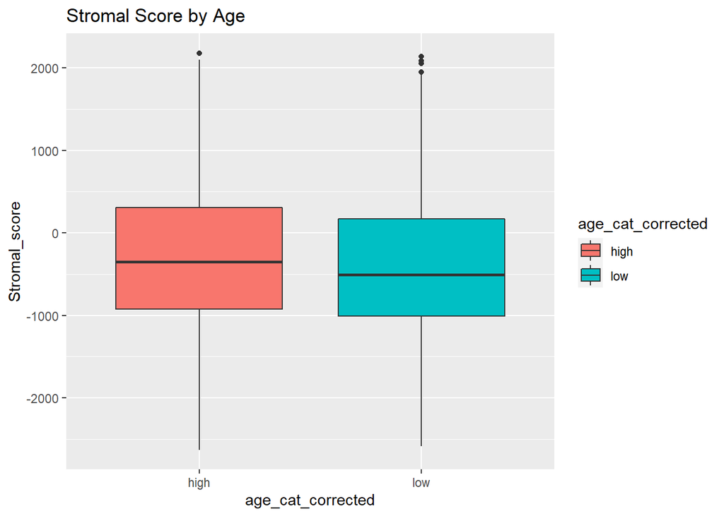

```r
stromal_age <- ggplot(TCGAEstimate_age_corrected, aes(x=age_cat_corrected, y=Stromal_score, fill=age_cat_corrected)) + geom_boxplot() + ggtitle("Stromal Score by Age")
stromal_age
```

### Immune score by age

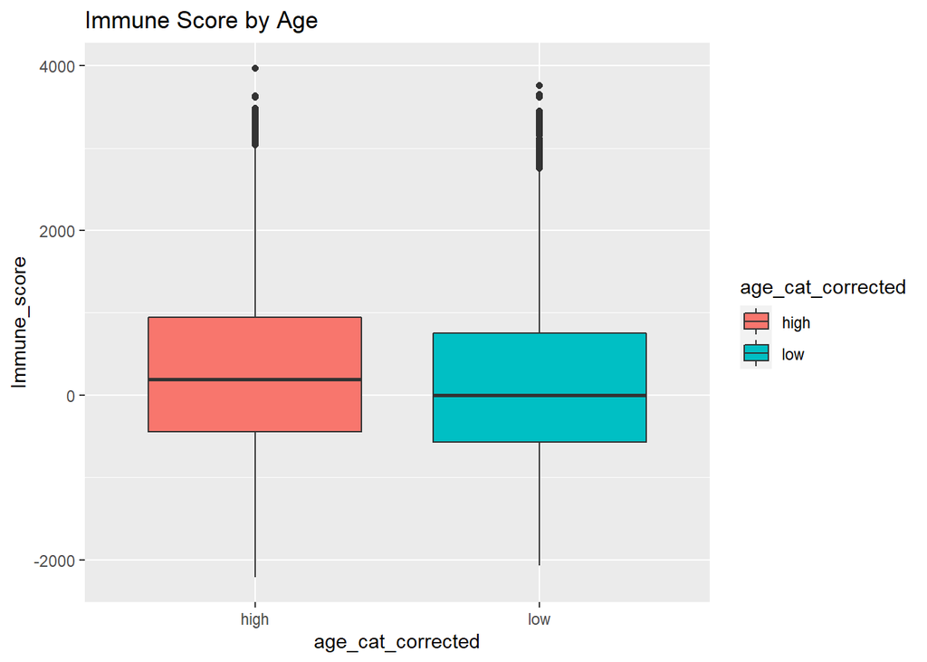

```r
immune_age <- ggplot(TCGAEstimate_age_corrected, aes(x=age_cat_corrected, y=Immune_score, fill=age_cat_corrected)) + geom_boxplot() + ggtitle("Immune Score by Age")
immune_age
```

### ESTIMATE score by age

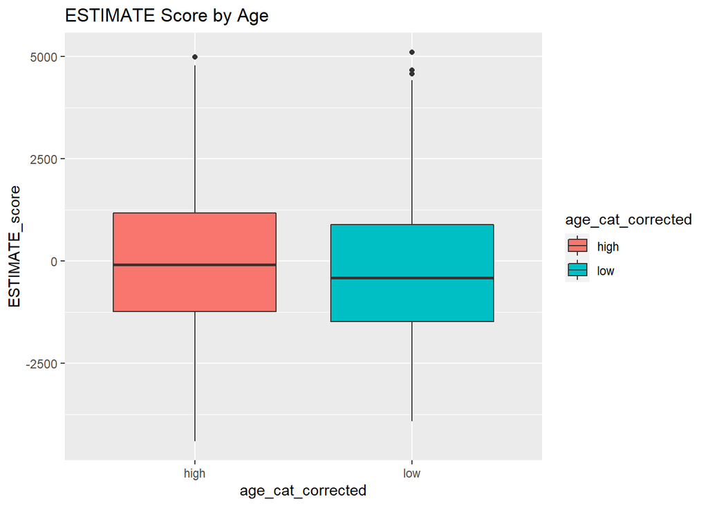

```r
estimate_age <- ggplot(TCGAEstimate_age_corrected, aes(x=age_cat_corrected, y=ESTIMATE_score, fill=age_cat_corrected)) + geom_boxplot() + ggtitle("ESTIMATE Score by Age")
estimate_age
```

### All arranged into one

[figure not shown]

```r
grid.arrange(stromal_age, immune_age, estimate_age, nrow=1, ncol=3)
```

[^1]: Now, tumor “stroma” includes basement membrane, fibroblasts, extracellular matrix, immune cells, and vasculature. Stromal cell consists of the type of cells that make up a certain types of connective tissue (supporting tissue that surrounds other tissues and organs). https://www.cancer.gov/publications/dictionaries/cancer-terms/def/stromal-cell